# Effect of Family Income on "Own Family" Members in a Household

## Authors: Kareem Safieddine, Marcus Cheema, Dylan Parker

[figure not shown]

- Introduction
- Literature Review
- Data
- Descriptive Statistics
- Getting Percentage by Demographic
- Summary Statistics Analysis
- Plotting Graphs
- Plot Analysis
- Hypothesis Testing with Lambda
- Conclusion

## Introduction

### Research Question: Do families with high income have a larger number of "own family" members in their households?

### Motivation:

Since the 1960s, the U.S. has seen a constant decline in fertility rates. The number of live births per 100 women went from 12 in 1960 to less than 6 in 2020 (Bendix and Murphy 2023). It is important to ask if the decline in fertility and decrease in family size is motivated by difficult financial times. According to Kenneth Johnson from the University of New Hampshire, the Great Recession reduced births by almost 2.3 million between 2008 and 2013. Clearly, this shows that there is a correlation between financial weakness and the amount of children people have. But, we seek to understand the correlation between financial strength and the amount of children people have. Even though people have less kids when they are going through difficult financial times, does that necessarily mean that they will have more children? Some might argue that more income is correlated with a higher education, which is usually also correlated with delaying the time until people have children or the amount of children people have. Nonetheless, this project will investigate this relationship to see if it is true. Beyond fertility rates, this research will help us analyze how many families are living with extended family members and if that is influenced by total income. It will reveal key dynamics in family and household structures.

### Importance:

Understanding the intricacies of family size dynamics would better allow us to tackle the decreasing fertility rate in economically advanced countries. Many studies conclude that difficult financial times decrease the amount of children being born, but what if that is still the case in times of financial strength? Our question will be able to identify a clear relationship between family income and the number of members in the household. It could even reveal the direction of this relationship: does high income lead to many children or do many children lead to a high income? Regardless, the financial logic behind the composition of a family is integral in the battle against the changing demographics in the United States and across other developed countries.

## Literature Review

### Article 1:

**Female relative wages, household specialization and fertility (Christian Siegel) - Review of Economic Dynamics -** Falling fertility is strongly correlated with rising female wages. But, despite decreasing fertility, the last 40 years have shown relatively stable fertility rates in the U.S. in relationship to continuously growing female wages. Women’s hours spent on housework have decline, but mens have increased. The stagnation of fertility decline can be due to new forms of household specialization. The cost of having a child can change for a woman if they man decides to take on more household work. The article concludes that when the wage gap decreases, women’s labor supply increases and total home production falls. Because men’s wages are higher than their wives, they are not offsetting the drop in women’s time working at home, and it causes fertility to fall. The research concludes that fertility decline ends when female relative wages improve, in combination with mutual specialization between both parents in terms of working at home.

### Article 2:

**Human fertility in relation to education, economy, religion, contraception, and family planning programs (Götmark and Andersson 2020) - BMC Public Health -** This article looks at the relationship between fertility and different things like education, the economy, and religion. It states that the family size reduces as nations and economics develop due to increasing income per capita and a trade-off between quantity and quality of children. In more advanced economies, the cost of children is high and presents opportunity costs for child-rearing women in job markets. This creates an expectation for higher investments into fewer children and leads to a decrease in the total fertility rate. The article is very clear about how industrial production favors child quality over quantity which turns attention to the education of the child and smaller families. GDP is increasingly positive for countries with lower TFR level, so there is an argument to be made that the relationship is flipped and lower number of children lets to higher family income.

### Article 3:

**Salaries, degrees, and babies: Trend in fertility by income and education among Japanese men and women born 1943-1975 - Analysis of national surveys (Ghaznavi et al. 2022) - PLOS ONE -** This article is interesting because it analyzes the impacts of income and education on men and women individually. The research concludes that men with university degrees were more likely to have children than those without a degree in all birth cohorts except 1943-47. Men with higher income were more likely to have children. The proportion of men having children was decreasing for all income groups, but it was decreasing much more for the lowest income groups. For women, those with a university degree were less likely to have children than those without. This pattern was not seen for women born in 1971-1975. Nonetheless, men with lower education and income were less likely to have children.

### Article 4:

**The Impact of the Main Negative Socio-Economic Factors on Female Fertility (Tarca et al.) - National Library of Medicine -** The article describes that there is a known negative relationship between fertility and income. It runs a regression model that concludes that the negative factor with the greatest impact on female fertility is the level of income per capita. The negative effects of smoking, alcohol consumption, and body weight have a lower impact on fertility than income per capita. The article states that their model concludes “exceeding the median level of income per capita by a certain country…leads to a decrease in the crude birth rate by 8.65%.” The conclusion is less children with more income.

### Article 5:

**Family Size and Men’s Labor Market Outcomes: Do Social Beliefs About Men’s Roles in the Family Matter? (Baranowska-Rataj and Matysiak 2022). - Taylor and Francis Online -** The article states that family size has a positive correlation with a father’s labor market outcomes in Europe. The research finds that, on average, the birth of a child is associated with a four percentage-point increase in the father’s share of hours worked. Having more children leads to better work outcomes. It warrants the reversal of the logic of our question: having more children leads to higher job ranks, wages, and more job stability. The family size could potentially have a higher impact on total family income rather than the other way around.

### Article 6:

**Relationship Between Income, Family Size, and Family Relationships (Pristina Rosalyn and Divya Dovina) - International Journal of Scientific Research -** This research paper seeks to find some relationship between income and family size and family size and family relationships. It makes an interesting argument that family size could impact family income rather than the other way around: the more children a family has, the more the resources of the family are diluted. This could be a strong argument against having large families in general. This article makes the case for the reversal of the direction of our question. The results and discussion section states “the more number of children in a family, the more does the parent(s) have to earn and provide for them. This can lead to increasing pressure in parents which they take upon themselves so their children would not have to be deprived of the various benefits that money could bring.” So, in this case, even if a family had a reasonable income, having too many children can hinder the benefits of being a high income household.

## Data

### Data Source:

Our data comes from the Integrated Public Use Microdata Series (IPUMS USA). It consists of more than fifty samples of the American population drawn from fifteen federal censuses and American Community Surveys from 2000 until now. Different investigators collected data in a different way, but IPUMS homogenizes the results by assigning uniform codes for each sample. The database consists of microdata, which means that each record is on the individual level, and it’s numerically coded.

### Variables:

- **FAMSIZE**: The family size variable represents the number of own family members in the household. IPUMS’s description states “FAMSIZE counts the number of own family members residing with each individual, including the person her/himself. Persons not living with others related to them by blood, marriage/cohabiting partnership, or adoption are coded 1.”
- **FTOTINC**: The family total income variable represents the total income of a family. IPUMS’s description states “FTOTINC reports the total pre-tax money income earned by one’s family…from all sources for the previous year.” Income is expressed in contemporary dollars which means it does not adjust for inflation over time.

### Variable Clean-Up:

- We got our data from the year 2018. It is sufficient to show the relationship between our two variables over the year. Importantly, it is also prior to the COVID-19 pandemic which could have influenced both income and fertility.
- We dropped data outside of ages 14-65 to reflect the expected working age of an individual. The U.S Department of Labor set 14 years old as the minimum age for employment, and 65 is usually the expected age of retirement.
- We dropped FTOINC equal to 9,999,999 because IPUMS said that this just meant the data was not available.
- We dropped total family income less than zero to avoid data points reflecting individuals in debt.

## Descriptive Statistics

```python
# Find working directory on your local computer
import os
path = os.getcwd()
print(path)
```

```
/Users/dylanethan/Python
```

```python
# Import necessary packages
import numpy as np
import pandas as pd
import matplotlib.pyplot as plt
import seaborn as sns
from scipy.stats import ttest_ind
from statsmodels.stats.proportion import proportions_ztest
# Remove scientific notation
pd.options.display.float_format = '{:.4f}'.format
```

### Raw Data

```python
# Import data
project = pd.read_csv('/Users/dylanethan/Python/Data/usa_00004.csv')
# First few rows
project.head()
```

|  | YEAR | HHWT | FAMSIZE | SEX | AGE | RACE | RACED | FTOTINC |
| --- | --- | --- | --- | --- | --- | --- | --- | --- |
| 0 | 2018 | 75.0000 | 1 | 2 | 19 | 1 | 100 | 9999999 |
| 1 | 2018 | 75.0000 | 1 | 2 | 18 | 2 | 200 | 9999999 |
| 2 | 2018 | 118.0000 | 1 | 1 | 53 | 1 | 100 | 9999999 |
| 3 | 2018 | 43.0000 | 1 | 1 | 28 | 1 | 100 | 9999999 |
| 4 | 2018 | 16.0000 | 1 | 2 | 25 | 1 | 100 | 9999999 |

```python
# Get data info
project.info()
```

```
<class 'pandas.core.frame.DataFrame'>
RangeIndex: 3214539 entries, 0 to 3214538
Data columns (total 8 columns):
 #   Column   Dtype
---  ------   -----
 0   YEAR     int64
 1   HHWT     float64
 2   FAMSIZE  int64
 3   SEX      int64
 4   AGE      int64
 5   RACE     int64
 6   RACED    int64
 7   FTOTINC  int64
dtypes: float64(1), int64(7)
memory usage: 196.2 MB
```

```python
# Statistics for FTOTINC, FAMSIZE, SEX, AGE, RACE, fix format
project.agg({'FTOTINC' : ['mean', 'std', 'max', 'min', 'count'], 'FAMSIZE' : ['mean', 'std', 'max', 'min', 'count'],
            'SEX' : ['mean', 'std', 'max', 'min', 'count'], 'AGE' : ['mean', 'std', 'max', 'min', 'count'],
            'RACE' : ['mean', 'std', 'max', 'min', 'count']})
```

|  | FTOTINC | FAMSIZE | SEX | AGE | RACE |
| --- | --- | --- | --- | --- | --- |
| mean | 583119.5094 | 3.0305 | 1.5102 | 41.6345 | 1.8135 |
| std | 2141499.4622 | 1.7269 | 0.4999 | 23.7020 | 1.8880 |
| max | 9999999.0000 | 20.0000 | 2.0000 | 96.0000 | 9.0000 |
| min | -16400.0000 | 1.0000 | 1.0000 | 0.0000 | 1.0000 |
| count | 3214539.0000 | 3214539.0000 | 3214539.0000 | 3214539.0000 | 3214539.0000 |

### Data Clean-Up

```python
# Data clean-up
# Drop FTOTINC of 9999999 (9999999 means 'n/a')
mask = project['FTOTINC'] == 9999999
project = project.drop(project[mask].index)

# Drop FTOTINC <0
mask = project['FTOTINC'] < 0
project = project.drop(project[mask].index)

# Drop age ranges outside of 14-65
mask = project['AGE'] < 14
project = project.drop(project[mask].index)
mask = project['AGE'] > 65
project = project.drop(project[mask].index)

project.info()
```

```
<class 'pandas.core.frame.DataFrame'>
Int64Index: 2006830 entries, 2294 to 3214537
Data columns (total 8 columns):
 #   Column   Dtype
---  ------   -----
 0   YEAR     int64
 1   HHWT     float64
 2   FAMSIZE  int64
 3   SEX      int64
 4   AGE      int64
 5   RACE     int64
 6   RACED    int64
 7   FTOTINC  int64
dtypes: float64(1), int64(7)
memory usage: 137.8 MB
```

### Post Data Clean-Up

```python
# Statistics after data clean-up
project.agg({'FTOTINC' : ['mean', 'std', 'max', 'min', 'count'], 'FAMSIZE' : ['mean', 'std', 'max', 'min', 'count'],
            'SEX' : ['mean', 'std', 'max', 'min', 'count'], 'AGE' : ['mean', 'std', 'max', 'min', 'count'],
            'RACE' : ['mean', 'std', 'max', 'min', 'count']})
```

|  | FTOTINC | FAMSIZE | SEX | AGE | RACE |
| --- | --- | --- | --- | --- | --- |
| mean | 101616.0314 | 3.0911 | 1.5127 | 40.9494 | 1.8343 |
| std | 106938.2051 | 1.6344 | 0.4998 | 15.1880 | 1.8965 |
| max | 2580000.0000 | 20.0000 | 2.0000 | 65.0000 | 9.0000 |
| min | 0.0000 | 1.0000 | 1.0000 | 14.0000 | 1.0000 |
| count | 2006830.0000 | 2006830.0000 | 2006830.0000 | 2006830.0000 | 2006830.0000 |

## Getting Percentages by Demographic

### Getting percentages of female and male proportions

```python
### Sex
# Create "Female": 1 if female, 0 if not
project['Female'] = project['SEX']==2
# Convert to integer
project['Female'] = project['Female'].astype('int')
```

```python
### Percentages
# Percentage of females to males
len(project.axes[0])
totfem = 0
for i in project['Female']:
    if(i == 1):
        totfem = totfem + 1
percentage_female = round((totfem / len(project.axes[0])) * 100, 3)
percentage_male = round(100 - percentage_female, 3)
print("Percentage Female: " + str(percentage_female) + "%")
print("Percentage Male: " + str(percentage_male) + "%")
```

```
Percentage Female: 51.269%
Percentage Male: 48.731%
```

### Getting percentages of white, black, and other race proportions

```python
### Race
# 1 is white, 2 is black, not 1 or 2 is other
# White
project['White'] = project['RACE'] == 1
# Convert to integer
project['White'] = project['White'].astype('int')

# Black
project['Black'] = project['RACE'] == 2
project['Black'] = project['Black'].astype('int')
```

```python
### Percentages
# Percentage white
len(project.axes[0])
total_white = 0
for i in project['White']:
    if(i == 1):
        total_white = total_white + 1
percentage_white = round((total_white / len(project.axes[0])) * 100, 3)
print("Percentage White: " + str(percentage_white) + "%")

# Percentage black
total_black = 0
for i in project['Black']:
    if (i == 1):
        total_black = total_black + 1
percentage_black = round((total_black / len(project.axes[0])) * 100, 3)
print("Percentage Black: " + str(percentage_black) + "%")

# percentage other
percentage_other = round((100 - percentage_white - percentage_black), 3)
print("Percentage Other: " + str(percentage_other) + "%")
```

```
Percentage White: 76.483%
Percentage Black: 9.367%
Percentage Other: 14.15%
```

## Summary Statistics Analysis

- Our data (age 14-65 from year 2018) has a total of 2,006,830 entries. There is no apparent pattern within the summary statistics.
- **FTOINC**: The average family total income for our data set is \$101,616.03. The standard deviation for family total income is \\$106,938.2 which means that on average the data points vary \$106,938.2 from the mean. A higher standard deviation implies the data points for family total income are more spread out. The maximum amount of income in our data is \\$2,580,000 and the minimum is 0.
- **FAMSIZE**: The average family size of our data is 3.1 persons per family. The standard deviation for family size is 1.63 which means that on average the data points vary 1.63 persons from the mean. The maximum size for our data is 20, and the minimum is 1.
- **Sex**: 51% of the dataset comprises of females, while 49% are male.
- **Age**: The average age of an individual in our data is around 41 years old. The standard deviation is 15 years which means that on average the data points vary 15 years from the mean. The maximum age is 65 and the minimum age is 14, reflecting the typical working period during a lifespan.
- **Race**: 77% of the dataset comprises of the White population, while 9% are Black, and 14% are other races.

## Plotting Graphs

### Plot 1:

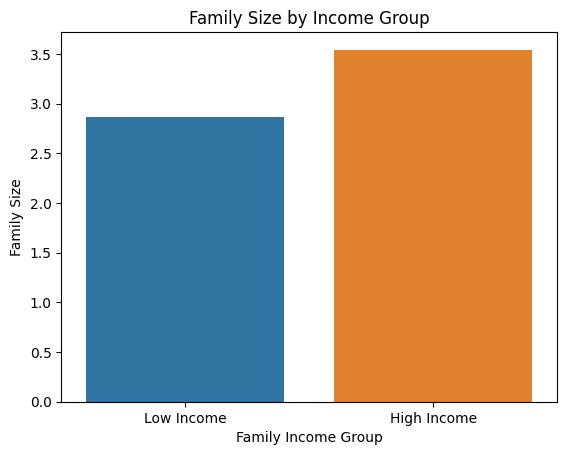

```python
### Plot barplot between FTOTINC and FAMSIZE
# Split income into 2 categories
group = ['Low Income', 'High Income']
limit = [0, 101616, 1000000000]
project['ftotinc_cat'] = pd.cut(project['FTOTINC'], bins=limit, labels=group)

bar = sns.barplot(data = project, x='ftotinc_cat', y='FAMSIZE', errorbar=None);
bar.set(title='Family Size by Income Group', xlabel='Family Income Group', ylabel='Family Size');
```

### Plot 2:

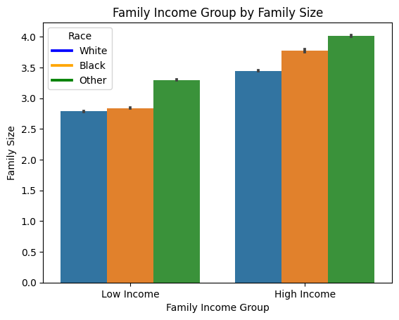

```python
### Bar plot based on Race
group = ['Low Income', 'High Income']
limit = [0, 101616, 9999999]     # mean and below is "low", above is "high"

# project['White'] = project['RACE'] == 1
# project['White_Inc'] = project.loc[project['White'], 'FTOTINC']
# print(project['White_Inc'].head())

# project['Black'] = project['RACE'] == 2
# project['Black_Inc'] = project.loc[project['Black'], 'FTOTINC']
# print(project['Black_Inc'].head())

#project['Other'] = (project['RACE'] != 1) (project['RACE'] != 2)
#project['Other_Inc'] = project.loc[project['Other'], 'FTOTINC']

# mean_white = project.loc[project['White'], 'FTOTINC'].mean()
# print(mean_white)

# if project['RACE'] == 1:
#     project['RACE_new'] = 'White'
# elif project['RACE'] == 2:
#     project['RACE_new'] = 'Black'
# else:
#     project['RACE_new'] = 'Other'
def f(x):
    if x==1:
        return 1
    elif x==2:
        return 2
    else:
        return 3

project['new_race_cat'] = project['RACE'].apply(f)

project['ftotinc_cat'] = pd.cut(project['FTOTINC'], bins = limit, labels = group)

bar = sns.barplot(data = project, x='ftotinc_cat', y='FAMSIZE', hue='new_race_cat');
bar.set(title = 'Family Income Group by Family Size', xlabel = 'Family Income Group', ylabel = 'Family Size');
legend = plt.legend(title = 'Race', labels = ['White', 'Black', 'Other']);
legend.get_lines()[0].set_color('blue')
legend.get_lines()[1].set_color('orange')
legend.get_lines()[2].set_color('green')
plt.show()
```

## Plot Analysis

### Plot 1:

The first plot shows the effect of income on family size. It has family income group (independent variable) on the x-axis and family size (dependent variable) on the y-axis. We divided high income and low income based on the mean family total income. Data points with income above the mean were considered high income, and data points with income below the mean were considered low income. Low income families had an average of around 2.8 person per family while high income families had an average of 3.5 person per family. This plot shows a positive relationship between income and family size. Families with high income tended to have larger family sizes, on average.

## Hypothesis Testing with Lambda

### Testing to see if there is a difference in mean family size between high and low income groups:

```python
# Create 2 groups by income group to compare family size
project['high_income'] = project['FTOTINC']>101616
project.groupby('high_income')['FAMSIZE'].apply(lambda x: list(x))
```

```
high_income
False    [4, 4, 4, 2, 2, 2, 2, 2, 4, 4, 4, 4, 3, 3, 3, ...
True     [4, 4, 4, 4, 4, 4, 2, 2, 8, 8, 8, 8, 8, 4, 4, ...
Name: FAMSIZE, dtype: object
```

```python
# Test for difference:
test_gen_lam = ttest_ind(*project.groupby('high_income')['FAMSIZE'].apply(lambda x: list(x)), alternative='less')
print("test-stat: ", round(test_gen_lam[0], 4))
print("p-value: ", round(test_gen_lam[1], 4))
```

```
test-stat:  -294.9044
p-value:  0.0
```

### Hypothesis Test Analysis 1

- $H_0$: Low income families have larger mean family sizes than high income families
- $H_a$: Low income families have smaller mean family sizes than high income families

Since there is a p-value of 0, the results are statistically significant. We reject the null hypothesis. This suggests that high income families have larger mean family sizes than low income families. The t-stat of -294.9044 also implies that there is very strong evidence that high income families have larger mean family sizes than low income families.

### Testing to see if there is a difference in mean family size between high and low income groups for the black population:

```python
# Create 2 groups by income group to compare family size of black population
project['high_income_black'] = ((project['FTOTINC'] > 101616) & (project['Black'] == 1))
project.groupby('high_income_black')['FAMSIZE'].apply(lambda x: list(x))
```

```
high_income_black
False    [4, 4, 4, 2, 2, 2, 2, 2, 4, 4, 4, 4, 3, 3, 3, ...
True     [4, 4, 4, 4, 5, 5, 5, 6, 6, 6, 4, 4, 4, 5, 5, ...
Name: FAMSIZE, dtype: object
```

```python
# Test for difference:
test_gen_lam = ttest_ind(*project.groupby('high_income_black')['FAMSIZE'].apply(lambda x: list(x)), alternative='less')
print("test-stat: ", round(test_gen_lam[0], 4))
print("p-value: ", round(test_gen_lam[1], 4))
```

```
test-stat:  -83.7931
p-value:  0.0
```

### Hypothesis Test Analysis 2

- $H_0$: Low income black families have larger mean family sizes than high income black families
- $H_a$: Low income black families have smaller mean family sizes than high income black families

### Testing to see if there is a difference in mean family size between high and low income groups for the white population:

```python
# Create 2 groups by income group to compare family size of black population
project['high_income_white'] = ((project['FTOTINC'] > 101616) & (project['White'] == 1))
project.groupby('high_income_white')['FAMSIZE'].apply(lambda x: list(x))
```

```
high_income_white
False    [4, 4, 4, 2, 2, 2, 2, 2, 4, 4, 4, 4, 3, 3, 3, ...
True     [4, 4, 4, 4, 4, 4, 2, 2, 8, 8, 8, 8, 8, 4, 4, ...
Name: FAMSIZE, dtype: object
```

```python
# Test for difference:
test_gen_lam = ttest_ind(*project.groupby('high_income_white')['FAMSIZE'].apply(lambda x: list(x)), alternative='less')
print("test-stat: ", round(test_gen_lam[0], 4))
print("p-value: ", round(test_gen_lam[1], 4))
```

```
test-stat:  -195.0841
p-value:  0.0
```

### Hypothesis Test Analysis 3

- $H_0$: Low income white families have larger mean family sizes than high income white families
- $H_a$: Low income white families have smaller mean family sizes than high income white families

## Conclusion

Our research question aimed to answer if families with high income have a larger number of “own family” members in their households. We were seeking to analyze how the economic conditions of the household influences their family structure, and this research was necessitated by the decreasing fertility rates in the status quo. These results have revealed key dynamics in family and household structures.

In either case, our results revealed there is a relationship between family income and family size. It could be the case that family income makes a family feel more secure with having more own family members in the household since they can afford it. On the other hand, it could be the case that having more own family members in the household means that there are more sources of income coming into the house. Regardless, these results can provide key insights on how economic conditions can influence family dynamics. Families with lower total family income consist of less own family members than families with a higher total family income. This reveals that economic conditions of the household puts strong pressure on the amount of people in the household. It can also mean that tougher economic conditions lead more families to pool their resources. Although we could not reveal the direction of our variables, we did conclude a clear correlation ship relation between family income and the number of members in the household.

Most of the articles cited at the beginning of our research had mixed conclusions about the relationship between income and fertility or family size. Our results fall in line with the group of articles who conclude that a higher fertility rate was a result of stronger economic conditions. Our results could not support the phenomena that more income led to lower fertility rates. This could be because our results did not capture the direct trade off between having a child and the income of the family.

Future research should attempt to collect more specific variables to clarify the relationship. If total income only collected the collected wages of the parents in the household and if the family size variable only looked at families with biological or adopted children and their parents, then it would make it easier to define a causal or stronger correlational relationship between family size and family income. It would also assist in clarifying the direction of the relationship between the two.

## Works Cited

Baranowska-Rataj, A., Matysiak, A. Family Size and Men’s Labor Market Outcomes: Do Social Beliefs About Men’s Roles in the Family Matter? Taylor&Francis Online, (2022). https://doi.org/10.1080/13545701.2021.2015076

Ghaznavi, C. et al. Salaries, degrees, and babies: Trends in fertility by income and education among Japanese men and women born 1943-1975-Analysis of national surveys. PLOS One, (2022). https://doi.org/10.1371/journal.pone.0266835

Götmark, F., Andersson, M. Human fertility in relation to education, economy, religion, contraception, and family planning programs. BMC Public Health 20, 265 (2020). https://doi.org/10.1186/s12889-020-8331-7

Rosalyn, P., Dovina, D. Relationship Between Income, Family Size and Family Relationships. International Journal of Scientific Research, (2019). https://doing.org/10.36106/ijsr

Siegel, C. Female relative wages, household specialization and fertility. Review of Economic Dynamics 24, (2017). https://doi.org/10.1016/j.red.2017.01.010

Tarca, V., Tarca, E., and Luca, F. The Impact of the Main Negative Socio-Economic Factors on Female Fertility. National Library of Medicine, (2022). https://doi.org/10.3390/healthcare10040734